# 13 Generative Adversarial Networks

**Key references**

- **GANs** — the original framework introducing the adversarial training paradigm: a generator network learns to produce realistic data by competing against a discriminator network (Goodfellow et al., 2014).
- **DCGAN** — deep convolutional GAN, which established stable architectures and training practices for image generation (Radford et al., 2016).
- **LSGAN** — least-squares GAN, a simple replacement of the saturating cross-entropy loss that is markedly more stable on small problems (Mao et al., 2017).

A **generative adversarial network** (GAN) sits inside a short block of chapters on generative models. Earlier chapters focused on architectures used for prediction, classification, or representation learning. In this part of the book, autoencoders, GANs, diffusion models, and flow matching are grouped together because they all learn data distributions and produce new samples, even though their training mechanisms differ substantially.

A GAN consists of two neural networks trained simultaneously in competition:

- The **generator** $G$ takes random noise $\mathbf{z}$ and produces a synthetic sample $G(\mathbf{z})$.
- The **discriminator** $D$ receives either a real or a generated sample and tries to tell them apart.

Training alternates between improving the discriminator (so it better distinguishes real from fake) and improving the generator (so its fakes become more convincing). The result is a generator that can produce realistic, novel samples from the data distribution.

## 13.1 The adversarial objective

The original GAN training objective is a minimax game:

$$\min_G \max_D \; \mathbb{E}_{\mathbf{x} \sim p_{\text{data}}}\!\bigl[\log D(\mathbf{x})\bigr] + \mathbb{E}_{\mathbf{z} \sim p_{\mathbf{z}}}\!\bigl[\log\bigl(1 - D(G(\mathbf{z}))\bigr)\bigr]$$

At convergence, the generator produces samples that the discriminator cannot distinguish from real data. In practice, GANs can be difficult to train: the generator and discriminator must be balanced, the log-loss saturates when the discriminator gets ahead, and training can be unstable.

The **least-squares GAN** (Mao et al., 2017) replaces the log loss with mean-squared error:

$$\begin{aligned}
\mathcal{L}_D &= \tfrac{1}{2}\,\mathbb{E}\bigl[(D(\mathbf{x}) - 1)^2\bigr] + \tfrac{1}{2}\,\mathbb{E}\bigl[D(G(\mathbf{z}))^2\bigr], \\
\mathcal{L}_G &= \tfrac{1}{2}\,\mathbb{E}\bigl[(D(G(\mathbf{z})) - 1)^2\bigr].
\end{aligned}$$

Conceptually the discriminator is now a regressor that scores realism rather than a classifier. The gradient does not vanish when fakes are easy to spot, so the generator keeps getting useful signal. For small chapter-sized problems LSGAN is almost always the right starting point — it is one of the simplest reliable GAN variants.

## 13.2 Architecture

The original GAN used feedforward networks for both $G$ and $D$. The **DCGAN** (Radford et al., 2016) established best practices for convolutional GANs on images:

- **Generator**: uses transposed convolutions to upsample noise into an image.
- **Discriminator**: uses standard convolutions to classify images as real or fake.
- Batch normalisation, LeakyReLU in the discriminator, and ReLU in the generator improve stability.

For 1D signals such as well logs or seismic traces, the same recipe works with 1D convolutions or — for short sequences — with plain dense layers, which is what we use below.

## 13.3 Code example: generating synthetic well logs with LSGAN

We train a GAN to generate synthetic 128-sample **well logs** that look like noisy gamma-ray traces. Each real log is a sequence of layered facies with sharp transitions — a low (clean-sand-like) value of about $0.25$ in one facies, a higher (shale-like) value of about $0.75$ in the other, with random segment lengths and within-segment noise. This is a useful GAN target because the real distribution has clear structure that is not captured by simple per-sample statistics: the mean of any well log will sit somewhere near $0.5$, but a random number near $0.5$ is *not* a plausible log. A successful generator must reproduce the **blocky, sharp-transition character** of the data.

```julia
using Lux, Random, Optimisers, Zygote, Statistics, Printf, CairoMakie

rng = Xoshiro(42)
n_depth = 128
```

```
128
```

```julia
# Synthetic gamma-ray-like well log: blocky facies + small within-segment noise.
function make_well_log(rng, n = n_depth)
    log_curve = zeros(Float32, n)
    pos = 1
    while pos <= n
        facies_value = rand(rng) < 0.5f0 ? 0.25f0 : 0.75f0
        seg_len      = rand(rng, 8:25)
        seg_end      = min(pos + seg_len - 1, n)
        for i in pos:seg_end
            log_curve[i] = facies_value + 0.04f0 * randn(rng, Float32)
        end
        pos = seg_end + 1
    end
    # Tiny moving-average smooth so transitions are not perfectly vertical.
    smoothed = copy(log_curve)
    for i in 2:n-1
        smoothed[i] = (log_curve[i-1] + log_curve[i] + log_curve[i+1]) / 3f0
    end
    return clamp.(smoothed, 0f0, 1f0)
end

n_real    = 1024
real_data = zeros(Float32, n_depth, n_real)
for i in 1:n_real
    real_data[:, i] = make_well_log(rng)
end
```

```julia
# Generator: latent noise → 128-sample log in [0, 1].
latent_dim = 8

generator = Chain(
    Dense(latent_dim => 64,      leakyrelu),
    Dense(64         => 128,     leakyrelu),
    Dense(128        => n_depth, sigmoid),
)

# Discriminator: 128-sample log → realism score (no output activation for LSGAN).
discriminator = Chain(
    Dense(n_depth => 64, leakyrelu),
    Dense(64      => 32, leakyrelu),
    Dense(32      => 1),
)

ps_g, st_g = Lux.setup(rng, generator)
ps_d, st_d = Lux.setup(rng, discriminator)
```

[output not shown]

```julia
function sample_batch(rng, data, batch_size)
    data[:, rand(rng, 1:size(data, 2), batch_size)]
end

function train_lsgan(ps_g, st_g, ps_d, st_d;
                     epochs = 1500, batch_size = 128,
                     lr = 2f-4)
    opt_state_g = Optimisers.setup(Adam(lr), ps_g)
    opt_state_d = Optimisers.setup(Adam(lr), ps_d)

    for epoch in 1:epochs
        #----- Discriminator step -----
        x_real = sample_batch(rng, real_data, batch_size)
        z      = randn(rng, Float32, latent_dim, batch_size)

        (d_loss, st_d_new), d_grads = Zygote.withgradient(ps_d) do pd
            fake, _              = generator(z, ps_g, st_g)
            real_score, st_d_a   = discriminator(x_real, pd, st_d)
            fake_score, st_d_b   = discriminator(fake,   pd, st_d_a)
            loss = 0.5f0 * (mean((real_score .- 1f0) .^ 2) +
                            mean(fake_score .^ 2))
            return loss, st_d_b
        end
        opt_state_d, ps_d = Optimisers.update(opt_state_d, ps_d, d_grads[1])
        st_d = st_d_new

        #----- Generator step -----
        z = randn(rng, Float32, latent_dim, batch_size)
        (g_loss, st_g_new), g_grads = Zygote.withgradient(ps_g) do pg
            fake, st_g_a    = generator(z, pg, st_g)
            fake_score, _   = discriminator(fake, ps_d, st_d)
            loss = 0.5f0 * mean((fake_score .- 1f0) .^ 2)
            return loss, st_g_a
        end
        opt_state_g, ps_g = Optimisers.update(opt_state_g, ps_g, g_grads[1])
        st_g = st_g_new

        if epoch == 1 || epoch % 300 == 0
            @printf "Epoch %4d  D loss = %.4f  G loss = %.4f\n" epoch d_loss g_loss
        end
    end
    return ps_g, st_g, ps_d, st_d
end

ps_g, st_g, ps_d, st_d = train_lsgan(ps_g, st_g, ps_d, st_d)
```

```
Epoch    1  D loss = 0.4374  G loss = 0.4185
Epoch  300  D loss = 0.1149  G loss = 0.2558
Epoch  600  D loss = 0.1120  G loss = 0.2898
Epoch  900  D loss = 0.0740  G loss = 0.4282
Epoch 1200  D loss = 0.0390  G loss = 0.4430
Epoch 1500  D loss = 0.0475  G loss = 0.3697
```

[output not shown]

```
Real mean / std: 0.498 / 0.245
Fake mean / std: 0.466 / 0.230
```

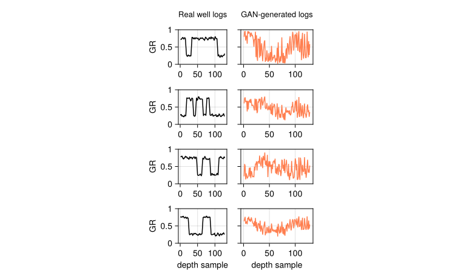

```julia
# Sanity-check distributions at the per-sample level.
z_test     = randn(rng, Float32, latent_dim, 256)
fake_data, _ = generator(z_test, ps_g, st_g)

@printf "Real mean / std: %.3f / %.3f\n"   mean(real_data) std(real_data)
@printf "Fake mean / std: %.3f / %.3f\n"   mean(fake_data) std(fake_data)

# The real test: visual similarity between real and generated logs.
fig = Figure(size = (760, 460))
Label(fig[0, 1], "Real well logs",        fontsize = 13)
Label(fig[0, 2], "GAN-generated logs",    fontsize = 13)

depth = collect(1:n_depth)
n_show = 4
for k in 1:n_show
    ax_r = Axis(fig[k, 1], xlabel = (k == n_show ? "depth sample" : ""),
                ylabel = "GR", yticks = ([0, 0.5, 1], ["0", "0.5", "1"]))
    lines!(ax_r, depth, real_data[:, k], color = :black)
    ylims!(ax_r, 0, 1)

    ax_f = Axis(fig[k, 2], xlabel = (k == n_show ? "depth sample" : ""),
                ylabel = "", yticks = ([0, 0.5, 1], ["", "", ""]))
    lines!(ax_f, depth, fake_data[:, k], color = :coral)
    ylims!(ax_f, 0, 1)
end
fig
```

The means and standard deviations are reported only as a sanity check; as the previous chapters warn, scalar summaries are not sufficient to declare GAN training successful.

## 13.4 When to use GANs

GANs excel at **generating realistic samples** from a learned distribution. They are particularly useful when:

- You need to **augment** limited training data with realistic synthetic examples.
- You want to **sample** from a complex distribution (e.g., geological models consistent with observations).
- You need to **transfer styles** or transform between domains (e.g., converting sketches to realistic geological cross-sections).

GANs can be harder to train than other generative models (VAEs, diffusion models). Mode collapse (the generator produces only a few types of output) and training instability are common challenges; switching from the original log loss to LSGAN, WGAN, or WGAN-GP almost always helps when problems arise.

## 13.5 Geoscience milestones

- **Porous media reconstruction** — Mosser et al. (2017) used DCGANs to generate 3D micro-CT-scale porous media samples that match real rock statistics, the first widely cited demonstration of generative deep learning on subsurface microstructure.
- **GAN-based geological priors for inversion** — Laloy et al. (2018) established the spatial GAN as a training-image-consistent prior for geostatistical inverse problems, allowing inversion to stay within geologically realistic model space.
- **Stochastic seismic inversion** — Mosser et al. (2020) combined a GAN prior with seismic inversion to produce ensembles of subsurface models consistent with both seismic data and geological knowledge.

Goodfellow, I., Pouget-Abadie, J., Mirza, M., Xu, B., Warde-Farley, D., Ozair, S., Courville, A., & Bengio, Y. (2014). Generative adversarial nets. *Advances in Neural Information Processing Systems*, *27*.

Laloy, E., Hérault, R., Jacques, D., & Linde, N. (2018). Training-image based geostatistical inversion using a spatial generative adversarial neural network. *Water Resources Research*, *54*(1), 381–406. https://doi.org/10.1002/2017WR022148

Mao, X., Li, Q., Xie, H., Lau, R. Y. K., Wang, Z., & Smolley, S. P. (2017). Least squares generative adversarial networks. *Proceedings of the IEEE International Conference on Computer Vision (ICCV)*, 2794–2802. https://doi.org/10.1109/ICCV.2017.304

Mosser, L., Dubrule, O., & Blunt, M. J. (2017). Reconstruction of three-dimensional porous media using generative adversarial neural networks. *Physical Review E*, *96*(4), 043309. https://doi.org/10.1103/PhysRevE.96.043309

Mosser, L., Dubrule, O., & Blunt, M. J. (2020). Stochastic seismic waveform inversion using generative adversarial networks as a geological prior. *Mathematical Geosciences*, *52*, 53–79. https://doi.org/10.1007/s11004-019-09832-6

Radford, A., Metz, L., & Chintala, S. (2016). Unsupervised representation learning with deep convolutional generative adversarial networks. *Proceedings of the International Conference on Learning Representations (ICLR)*. https://arxiv.org/abs/1511.06434